# Attempts at Connecting Fluctuations in the Gut Microbiome with the Development of Human Hepatocellular Carcinoma

## 9.3 MAPK10

MAPK10 is supposed to be up-regulated in nontumor samples…

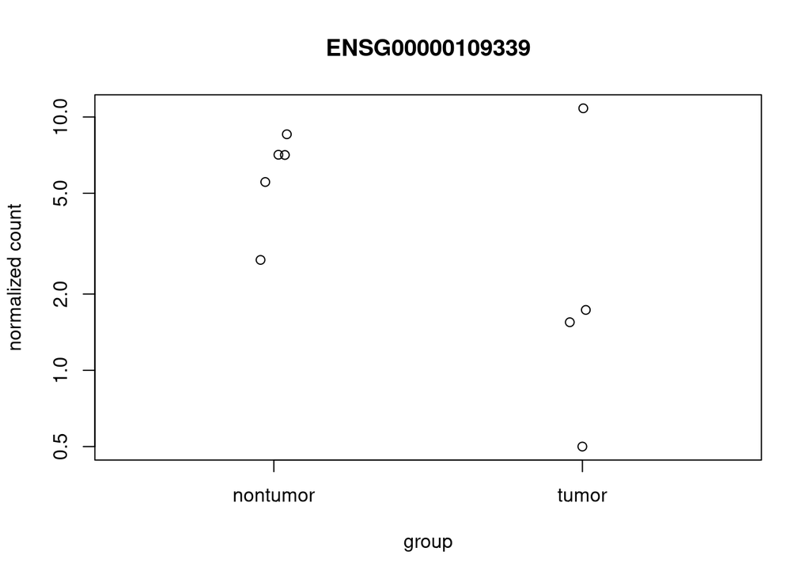

```r
# make the scatter plot
plotCounts(dds, "ENSG00000109339")
```

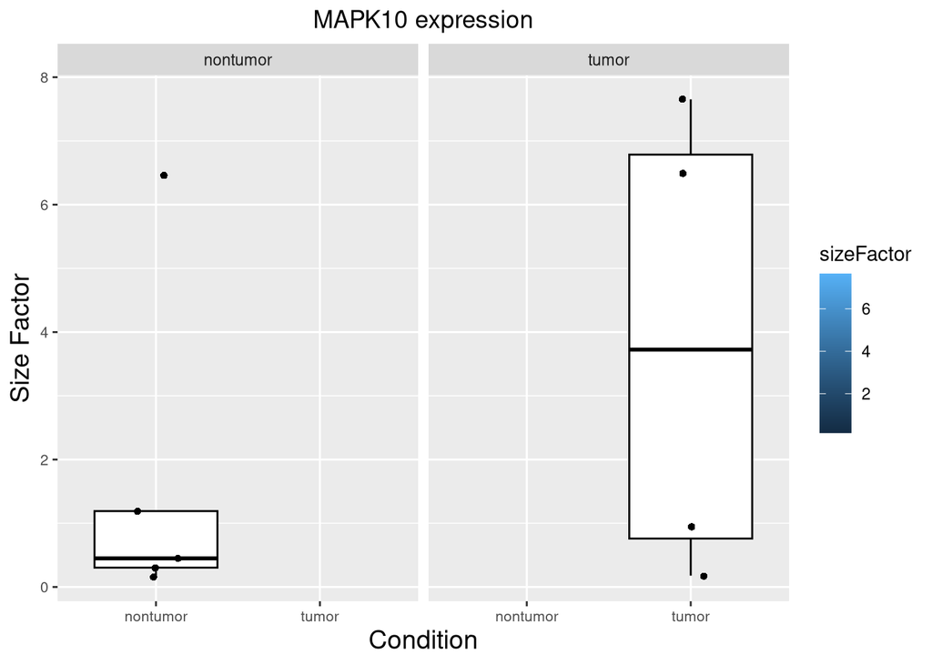

```r
# make the boxplot

#pdf(file = "MAPK10_boxplot.pdf", height = 2.5, width = 6)
MAPK10 <- plotCounts(dds,
                  gene = "ENSG00000109339",
                  intgroup = c("sizeFactor", "condition"),
                  returnData = TRUE) |>
  ggplot(aes(x = condition,
             y = sizeFactor,
             fill = sizeFactor)) +
  geom_boxplot(outlier.shape = NA, color = "black") +
  geom_jitter(shape = 16, position = position_jitter(0.2)) +
  labs(title = "MAPK10 expression",
       y = "Size Factor",
       x = "Condition") +
  theme_grey() +
  theme(plot.title = element_text(hjust = 0.5),
        axis.text = element_text(size = 8),
        axis.title = element_text(size = 14)) +
  facet_grid(~condition)
#dev.off()

print(MAPK10)
```

## 9.4 GPBAR1

GPBAR1 has functions in tumorigenesis of hepatocytes and mesenchymal immune cells. It is supposed to be up-regulated in tumor samples…

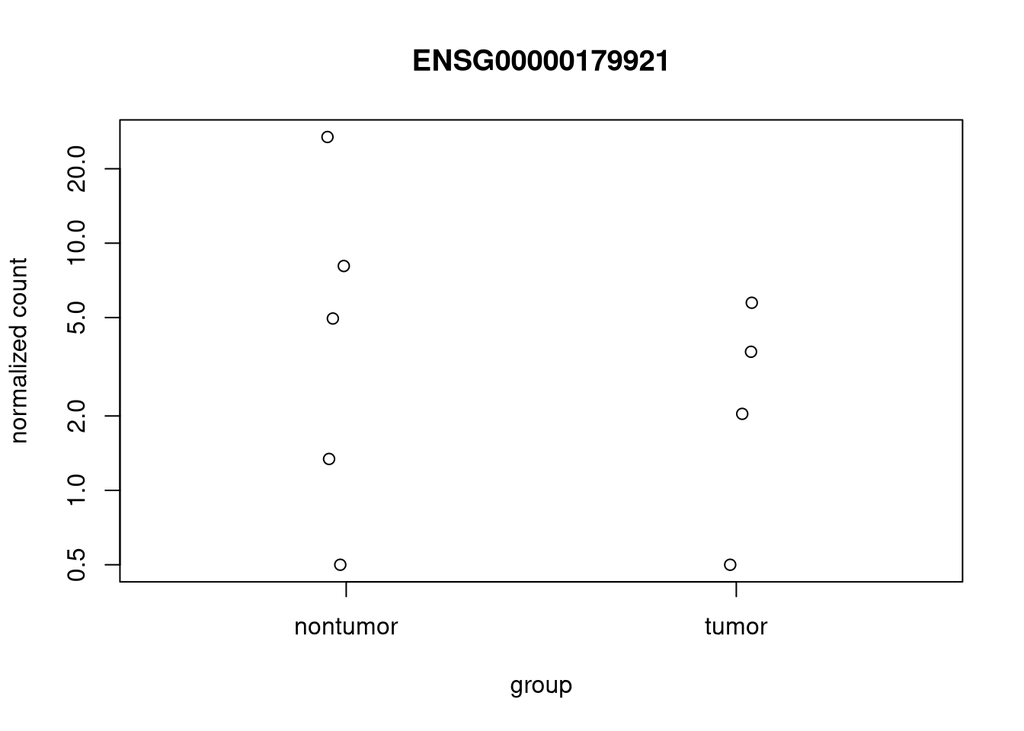

```r
# make the scatter plot
plotCounts(dds, "ENSG00000179921")
```

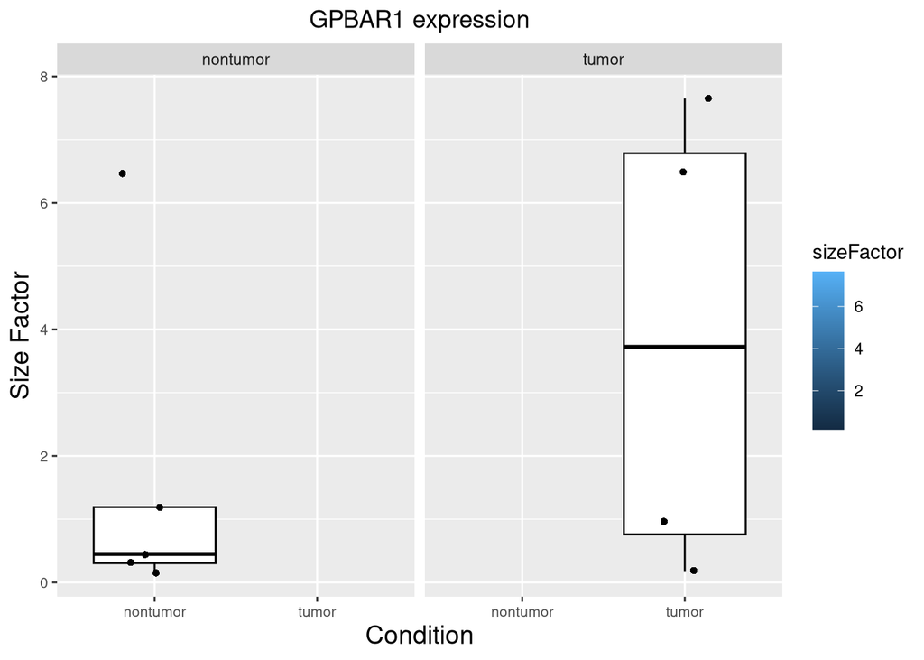

```r
# make the boxplot

#pdf(file = "GPBAR1_boxplot.pdf", height = 2.5, width = 6)
GPBAR1 <- plotCounts(dds,
                  gene = "ENSG00000179921",
                  intgroup = c("sizeFactor", "condition"),
                  returnData = TRUE) |>
  ggplot(aes(x = condition,
             y = sizeFactor,
             fill = sizeFactor)) +
  geom_boxplot(outlier.shape = NA, color = "black") +
  geom_jitter(shape = 16, position = position_jitter(0.2)) +
  labs(title = "GPBAR1 expression",
       y = "Size Factor",
       x = "Condition") +
  theme_grey() +
  theme(plot.title = element_text(hjust = 0.5),
        axis.text = element_text(size = 8),
        axis.title = element_text(size = 14)) +
  facet_grid(~condition)
#dev.off()

print(GPBAR1)
```

## 9.5 ABCC4

ABCC4 is expressed in both tumor and nontumor in patients with high levels of bile acid, which may make bile acid a mediator of the communication between gut microbiota and HCC transcriptome, we expect ABCC4 to be equaly expressed in both the tumor and nontumor samples…

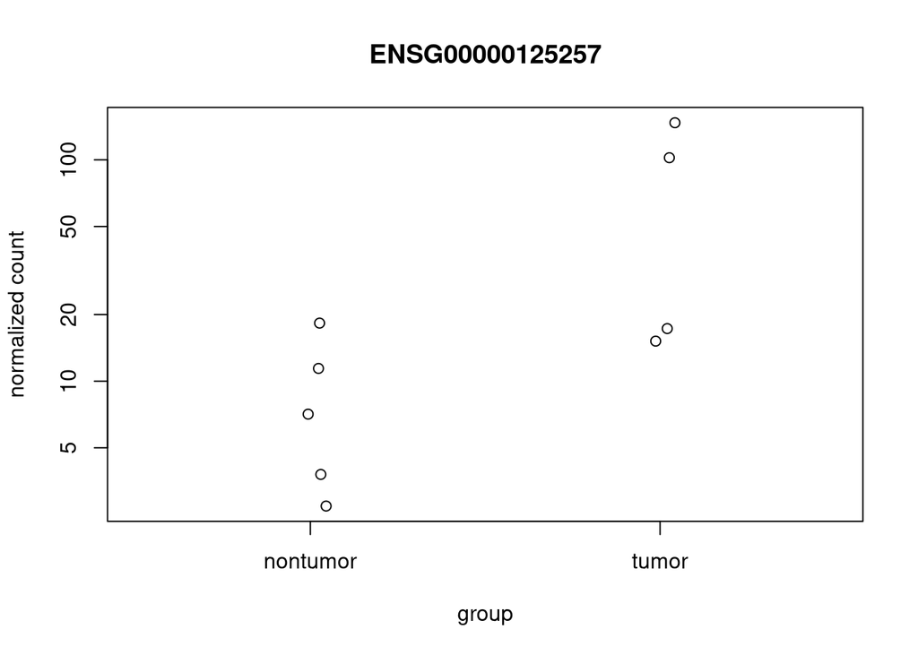

```r
# make the scatter plot
plotCounts(dds, "ENSG00000125257")
```

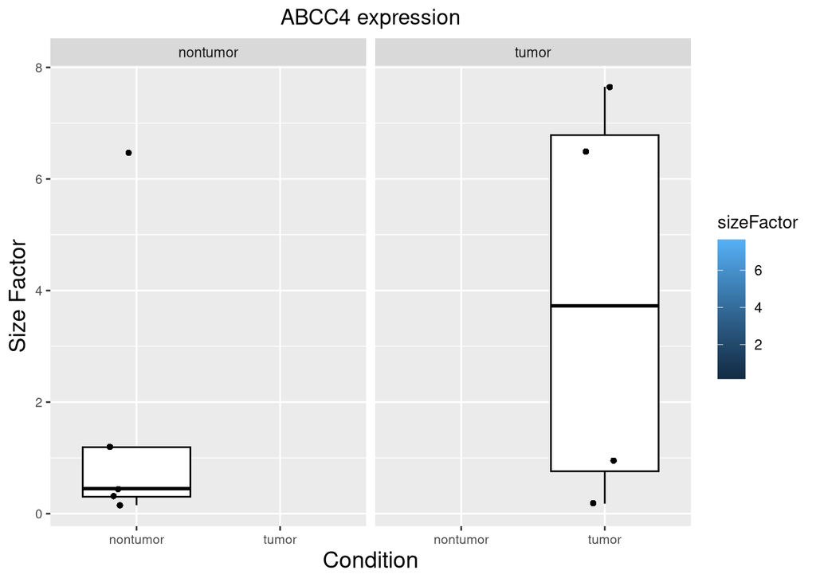

```r
# make the boxplot

#pdf(file = "ABCC4_boxplot.pdf", height = 2.5, width = 6)
ABCC4 <- plotCounts(dds,
                  gene = "ENSG00000125257",
                  intgroup = c("sizeFactor", "condition"),
                  returnData = TRUE) |>
  ggplot(aes(x = condition,
             y = sizeFactor,
             fill = sizeFactor)) +
  geom_boxplot(outlier.shape = NA, color = "black") +
  geom_jitter(shape = 16, position = position_jitter(0.2)) +
  labs(title = "ABCC4 expression",
       y = "Size Factor",
       x = "Condition") +
  theme_grey() +
  theme(plot.title = element_text(hjust = 0.5),
        axis.text = element_text(size = 8),
        axis.title = element_text(size = 14)) +
  facet_grid(~condition)
#dev.off()

print(ABCC4)
```